# (Loan Data from Prosper)

## Preliminary Wrangling

> This data set contains 113,937 loans with 81 variables on each loan, including loan amount, borrower rate (or interest rate), current loan status, borrower income, and many others.

```python
# import all packages and set plots to be embedded inline
import numpy as np
import pandas as pd
import matplotlib.pyplot as plt
import seaborn as sb

%matplotlib inline
```

> Load in the dataset and describe its properties through the questions below.

```python
df = pd.read_csv('prosperLoanData.csv')
```

```python
# high-level overview of data shape and composition
print(df.shape)
```

```
(113937, 81)
```

```python
df.info()
```

```
<class 'pandas.core.frame.DataFrame'>
RangeIndex: 113937 entries, 0 to 113936
Data columns (total 81 columns):
ListingKey                             113937 non-null object
ListingNumber                          113937 non-null int64
ListingCreationDate                    113937 non-null object
CreditGrade                            28953 non-null object
Term                                   113937 non-null int64
LoanStatus                             113937 non-null object
ClosedDate                             55089 non-null object
BorrowerAPR                            113912 non-null float64
BorrowerRate                           113937 non-null float64
LenderYield                            113937 non-null float64
EstimatedEffectiveYield                84853 non-null float64
EstimatedLoss                          84853 non-null float64
EstimatedReturn                        84853 non-null float64
ProsperRating (numeric)                84853 non-null float64
ProsperRating (Alpha)                  84853 non-null object
ProsperScore                           84853 non-null float64
ListingCategory (numeric)              113937 non-null int64
BorrowerState                          108422 non-null object
Occupation                             110349 non-null object
EmploymentStatus                       111682 non-null object
EmploymentStatusDuration               106312 non-null float64
IsBorrowerHomeowner                    113937 non-null bool
CurrentlyInGroup                       113937 non-null bool
GroupKey                               13341 non-null object
DateCreditPulled                       113937 non-null object
CreditScoreRangeLower                  113346 non-null float64
CreditScoreRangeUpper                  113346 non-null float64
FirstRecordedCreditLine                113240 non-null object
CurrentCreditLines                     106333 non-null float64
OpenCreditLines                        106333 non-null float64
TotalCreditLinespast7years             113240 non-null float64
OpenRevolvingAccounts                  113937 non-null int64
OpenRevolvingMonthlyPayment            113937 non-null float64
InquiriesLast6Months                   113240 non-null float64
TotalInquiries                         112778 non-null float64
CurrentDelinquencies                   113240 non-null float64
AmountDelinquent                       106315 non-null float64
```

[output cut: 31 more lines]

```
LP_CustomerPayments                    113937 non-null float64
LP_CustomerPrincipalPayments           113937 non-null float64
LP_InterestandFees                     113937 non-null float64
LP_ServiceFees                         113937 non-null float64
LP_CollectionFees                      113937 non-null float64
LP_GrossPrincipalLoss                  113937 non-null float64
LP_NetPrincipalLoss                    113937 non-null float64
LP_NonPrincipalRecoverypayments        113937 non-null float64
PercentFunded                          113937 non-null float64
Recommendations                        113937 non-null int64
InvestmentFromFriendsCount             113937 non-null int64
InvestmentFromFriendsAmount            113937 non-null float64
Investors                              113937 non-null int64
dtypes: bool(3), float64(50), int64(11), object(17)
memory usage: 68.1+ MB
```

```python
df.head(10)
```

|  | ListingKey | ListingNumber | ListingCreationDate | CreditGrade | Term | LoanStatus | ClosedDate | BorrowerAPR | BorrowerRate | LenderYield | ... | LP_ServiceFees | LP_CollectionFees | LP_GrossPrincipalLoss | LP_NetPrincipalLoss | LP_NonPrincipalRecoverypayments | PercentFunded | Recommendations | InvestmentFromFriendsCount | InvestmentFromFriendsAmount | Investors |
| --- | --- | --- | --- | --- | --- | --- | --- | --- | --- | --- | --- | --- | --- | --- | --- | --- | --- | --- | --- | --- | --- |
| 0 | 1021339766868145413AB3B | 193129 | 2007-08-26 19:09:29.263000000 | C | 36 | Completed | 2009-08-14 00:00:00 | 0.16516 | 0.1580 | 0.1380 | ... | -133.18 | 0.0 | 0.0 | 0.0 | 0.0 | 1.0 | 0 | 0 | 0.0 | 258 |
| 1 | 10273602499503308B223C1 | 1209647 | 2014-02-27 08:28:07.900000000 | NaN | 36 | Current | NaN | 0.12016 | 0.0920 | 0.0820 | ... | 0.00 | 0.0 | 0.0 | 0.0 | 0.0 | 1.0 | 0 | 0 | 0.0 | 1 |
| 2 | 0EE9337825851032864889A | 81716 | 2007-01-05 15:00:47.090000000 | HR | 36 | Completed | 2009-12-17 00:00:00 | 0.28269 | 0.2750 | 0.2400 | ... | -24.20 | 0.0 | 0.0 | 0.0 | 0.0 | 1.0 | 0 | 0 | 0.0 | 41 |
| 3 | 0EF5356002482715299901A | 658116 | 2012-10-22 11:02:35.010000000 | NaN | 36 | Current | NaN | 0.12528 | 0.0974 | 0.0874 | ... | -108.01 | 0.0 | 0.0 | 0.0 | 0.0 | 1.0 | 0 | 0 | 0.0 | 158 |
| 4 | 0F023589499656230C5E3E2 | 909464 | 2013-09-14 18:38:39.097000000 | NaN | 36 | Current | NaN | 0.24614 | 0.2085 | 0.1985 | ... | -60.27 | 0.0 | 0.0 | 0.0 | 0.0 | 1.0 | 0 | 0 | 0.0 | 20 |
| 5 | 0F05359734824199381F61D | 1074836 | 2013-12-14 08:26:37.093000000 | NaN | 60 | Current | NaN | 0.15425 | 0.1314 | 0.1214 | ... | -25.33 | 0.0 | 0.0 | 0.0 | 0.0 | 1.0 | 0 | 0 | 0.0 | 1 |
| 6 | 0F0A3576754255009D63151 | 750899 | 2013-04-12 09:52:56.147000000 | NaN | 36 | Current | NaN | 0.31032 | 0.2712 | 0.2612 | ... | -22.95 | 0.0 | 0.0 | 0.0 | 0.0 | 1.0 | 0 | 0 | 0.0 | 1 |
| 7 | 0F1035772717087366F9EA7 | 768193 | 2013-05-05 06:49:27.493000000 | NaN | 36 | Current | NaN | 0.23939 | 0.2019 | 0.1919 | ... | -69.21 | 0.0 | 0.0 | 0.0 | 0.0 | 1.0 | 0 | 0 | 0.0 | 1 |
| 8 | 0F043596202561788EA13D5 | 1023355 | 2013-12-02 10:43:39.117000000 | NaN | 36 | Current | NaN | 0.07620 | 0.0629 | 0.0529 | ... | -16.77 | 0.0 | 0.0 | 0.0 | 0.0 | 1.0 | 0 | 0 | 0.0 | 1 |
| 9 | 0F043596202561788EA13D5 | 1023355 | 2013-12-02 10:43:39.117000000 | NaN | 36 | Current | NaN | 0.07620 | 0.0629 | 0.0529 | ... | -16.77 | 0.0 | 0.0 | 0.0 | 0.0 | 1.0 | 0 | 0 | 0.0 | 1 |

10 rows × 81 columns

```python
# Create a new dataframe with features of interset
col =['Term','BorrowerAPR', 'BorrowerRate', 'ProsperRating (Alpha)', 'EmploymentStatus', 'StatedMonthlyIncome', 'LoanOriginalAmount',
       'LoanOriginationDate','MonthlyLoanPayment']
df_n = df[col]
```

```python
df_n.head()
```

|  | Term | BorrowerAPR | BorrowerRate | ProsperRating (Alpha) | EmploymentStatus | StatedMonthlyIncome | LoanOriginalAmount | LoanOriginationDate | MonthlyLoanPayment |
| --- | --- | --- | --- | --- | --- | --- | --- | --- | --- |
| 0 | 36 | 0.16516 | 0.1580 | NaN | Self-employed | 3083.333333 | 9425 | 2007-09-12 00:00:00 | 330.43 |
| 1 | 36 | 0.12016 | 0.0920 | A | Employed | 6125.000000 | 10000 | 2014-03-03 00:00:00 | 318.93 |
| 2 | 36 | 0.28269 | 0.2750 | NaN | Not available | 2083.333333 | 3001 | 2007-01-17 00:00:00 | 123.32 |
| 3 | 36 | 0.12528 | 0.0974 | A | Employed | 2875.000000 | 10000 | 2012-11-01 00:00:00 | 321.45 |
| 4 | 36 | 0.24614 | 0.2085 | D | Employed | 9583.333333 | 15000 | 2013-09-20 00:00:00 | 563.97 |

```python
df_n.info()
```

```
<class 'pandas.core.frame.DataFrame'>
RangeIndex: 113937 entries, 0 to 113936
Data columns (total 9 columns):
Term                     113937 non-null int64
BorrowerAPR              113912 non-null float64
BorrowerRate             113937 non-null float64
ProsperRating (Alpha)    84853 non-null object
EmploymentStatus         111682 non-null object
StatedMonthlyIncome      113937 non-null float64
LoanOriginalAmount       113937 non-null int64
LoanOriginationDate      113937 non-null object
MonthlyLoanPayment       113937 non-null float64
dtypes: float64(4), int64(2), object(3)
memory usage: 7.8+ MB
```

### Assessing and Cleaning

```python
#Checking EmploymentStatus values
print(df_n['EmploymentStatus'].unique())
```

```
['Self-employed' 'Employed' 'Not available' 'Full-time' 'Other' nan
 'Not employed' 'Part-time' 'Retired']
```

```python
# Fill nan values with 'Not available'
df_n['EmploymentStatus'].fillna(value='Not available', inplace=True)
```

[output not shown]

```python
#Check
df_n.info()
```

```
<class 'pandas.core.frame.DataFrame'>
RangeIndex: 113937 entries, 0 to 113936
Data columns (total 9 columns):
Term                     113937 non-null int64
BorrowerAPR              113912 non-null float64
BorrowerRate             113937 non-null float64
ProsperRating (Alpha)    84853 non-null object
EmploymentStatus         113937 non-null object
StatedMonthlyIncome      113937 non-null float64
LoanOriginalAmount       113937 non-null int64
LoanOriginationDate      113937 non-null object
MonthlyLoanPayment       113937 non-null float64
dtypes: float64(4), int64(2), object(3)
memory usage: 7.8+ MB
```

- 25 missing values from BorrowerAPR.
- We are going to calculate the median differnce betrwee BorrowerAPR and BorrowerRate
- Add the the median to BorrowerRate to get the missing BorrwerAPR

```python
diff = df_n["BorrowerAPR"] - df_n["BorrowerRate"]
diff.median()
```

```
0.025019999999999987
```

```python
df_n["BorrowerAPR"].fillna(df_n["BorrowerRate"] + diff.median(), inplace=True)

#Check
df_n["BorrowerAPR"].isnull().sum()
```

```
0
```

```python
#Rename a ProsperRating column
df_n.rename(columns={'ProsperRating (Alpha)': 'ProsperRating'}, inplace=True)
```

[output not shown]

```python
#Check
df_n.info()
```

```
<class 'pandas.core.frame.DataFrame'>
RangeIndex: 113937 entries, 0 to 113936
Data columns (total 9 columns):
Term                   113937 non-null int64
BorrowerAPR            113937 non-null float64
BorrowerRate           113937 non-null float64
ProsperRating          84853 non-null object
EmploymentStatus       113937 non-null object
StatedMonthlyIncome    113937 non-null float64
LoanOriginalAmount     113937 non-null int64
LoanOriginationDate    113937 non-null object
MonthlyLoanPayment     113937 non-null float64
dtypes: float64(4), int64(2), object(3)
memory usage: 7.8+ MB
```

```python
#Dropping nan records
df_n.dropna(inplace=True)
```

[output not shown]

```python
df_n.info()
```

```
<class 'pandas.core.frame.DataFrame'>
Int64Index: 84853 entries, 1 to 113936
Data columns (total 9 columns):
Term                   84853 non-null int64
BorrowerAPR            84853 non-null float64
BorrowerRate           84853 non-null float64
ProsperRating          84853 non-null object
EmploymentStatus       84853 non-null object
StatedMonthlyIncome    84853 non-null float64
LoanOriginalAmount     84853 non-null int64
LoanOriginationDate    84853 non-null object
MonthlyLoanPayment     84853 non-null float64
dtypes: float64(4), int64(2), object(3)
memory usage: 6.5+ MB
```

```python
#Convert LoanOriginationDate column to datetime type
df_n['LoanOriginationDate']= pd.to_datetime(df_n['LoanOriginationDate'])
```

[output not shown]

```python
df_n.info()
```

```
<class 'pandas.core.frame.DataFrame'>
Int64Index: 84853 entries, 1 to 113936
Data columns (total 9 columns):
Term                   84853 non-null int64
BorrowerAPR            84853 non-null float64
BorrowerRate           84853 non-null float64
ProsperRating          84853 non-null object
EmploymentStatus       84853 non-null object
StatedMonthlyIncome    84853 non-null float64
LoanOriginalAmount     84853 non-null int64
LoanOriginationDate    84853 non-null datetime64[ns]
MonthlyLoanPayment     84853 non-null float64
dtypes: datetime64[ns](1), float64(4), int64(2), object(2)
memory usage: 6.5+ MB
```

### What is the structure of your dataset?

> There are 84853 loans in the dataset with 9 features. Most variables are numirc in nature. EmploymentStatus is string type.

### What is/are the main feature(s) of interest in your dataset?

> I'm most interested in figuring out what features are best for predicting the borrower's Annual Percentage Rate (APR) for the loan.

### What features in the dataset do you think will help support your investigation into your feature(s) of interest?

> I expect that the LoanOriginalAmount will have the strongest effect APR : the larger the loan, the lower the APR. I also think that the Term, ProsperRating, EmploymentStatus, StatedMonthlyIncome and MonthlyLoanPayment will have effects on the APR, though to a much smaller degree than the main effect of LoanOriginalAmount .

## Univariate Exploration

> I'll start by looking at the distribution of the main variable of interest: APR

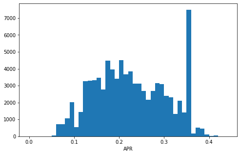

```python
# start with a standard-scaled plot
binsize = 0.025
bins = np.arange(0, df_n['BorrowerAPR'].max()+binsize, 0.01)

plt.figure(figsize=[8, 5])
plt.hist(data = df_n, x = 'BorrowerAPR', bins = bins)
plt.xlabel('APR')
plt.show()
```

The distribution of APR looks multimodal. A small peak centered around 0.1, a large peak around at 0.2. There is also a small peak centered 0.3. Additionally, there is a very shape peak between 0.35 and 0.36.

Next up, the first predictor variable of interest: LoanOriginalAmount

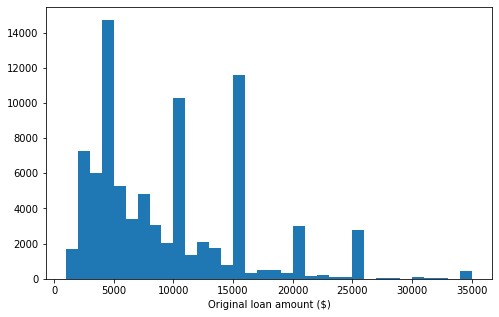

```python
bins = np.arange(1000, df_n.LoanOriginalAmount.max()+500, 1000)
plt.figure(figsize=[8, 5])
plt.hist(data = df_n, x = 'LoanOriginalAmount', bins = bins);
plt.xlabel('Original loan amount ($)');
```

There are spikes in frequency at 5k, 10k, 20k and 25k.

I'll now move on to the other variable in the dataset: stated monthly income

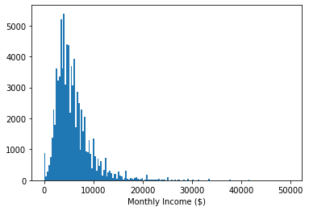

```python
# Distribution of stated monthly income
bins = np.arange(0, 50000, 300)
plt.hist(data = df_n, x = 'StatedMonthlyIncome', bins=bins);
plt.xlabel('Monthly Income ($)');
```

The distribution of the monthly income is right skewed, with most of monthly income less than 10K.

Next up: MonthlyLoanPayment

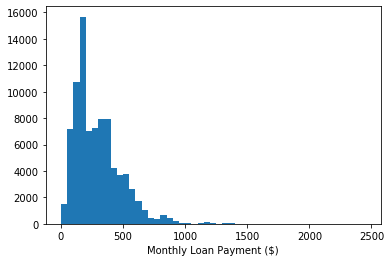

```python
# Distribution of stated monthly Loan payment
bins = np.arange(0, df_n.MonthlyLoanPayment.max()+200, 50)
plt.hist(data = df_n, x = 'MonthlyLoanPayment', bins=bins);
plt.xlabel('Monthly Loan Payment ($)');
```

Monthly Loan payment distrubtion looks rightly skewed. Most of the payments are less then 500

Next up we will look at ProsperRating.

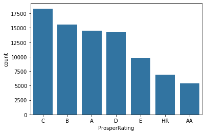

```python
base_color = sb.color_palette()[0]
rate_order = df_n.ProsperRating.value_counts().index
sb.countplot(data = df_n, x='ProsperRating', color=base_color, order=rate_order);
```

AA is the lowest risk down to HR which actually stands for high risk. Most accounts have average Prosper Rating.

Next up: Term

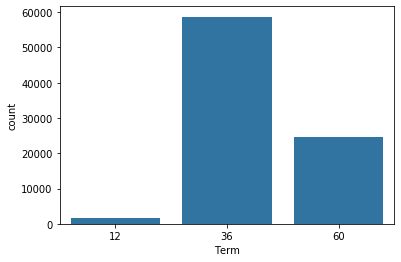

```python
sb.countplot(data = df_n, x = 'Term', color = base_color);
```

The length of most of the loans are 36 months.

Next: EmploymentStatus

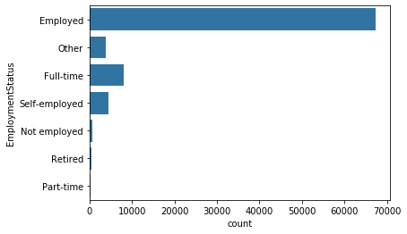

```python
sb.countplot(data = df_n, y = 'EmploymentStatus', color = base_color);
```

Most of borrowers are employed

### Discuss the distribution(s) of your variable(s) of interest. Were there any unusual points? Did you need to perform any transformations?

> The distribution of borrowers APR looks multimodal. Most of the values are at the range of 0.05 and 0.4. There are no unusual points and no need to perform any transformations.

### Of the features you investigated, were there any unusual distributions? Did you perform any operations on the data to tidy, adjust, or change the form of the data? If so, why did you do this?

> The disribution of both the monthly income and loan payments are higly right sckewed. Most of the income is less than 20k. And most of the payments are less than 1000. For safety, it is better to remove the points in which the income is greater then 20k and payments are greater than 1000. There is no need to perform any transformations.

## Bivariate Exploration

> To start off with, I want to look at the pairwise correlations present between features in the data.

```python
numeric_vars  = ['LoanOriginalAmount', 'BorrowerAPR', 'StatedMonthlyIncome', 'MonthlyLoanPayment']
categoric_vars  = ['Term', 'ProsperRating', 'EmploymentStatus']
```

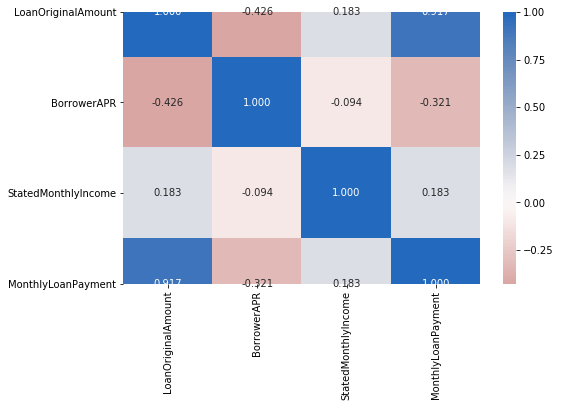

```python
# correlation plot
plt.figure(figsize = [8, 5])
sb.heatmap(df_n[numeric_vars].corr(), annot = True, fmt = '.3f',
           cmap = 'vlag_r', center = 0)
plt.show()
```

[output not shown]

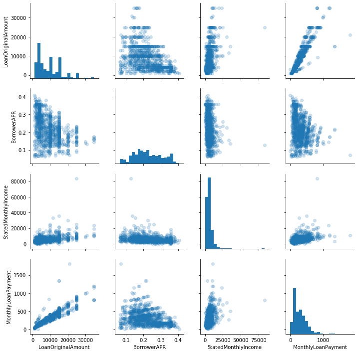

```python
# plot matrix: sample 1500 loans so that plots are clearer and
# they render faster
samples = np.random.choice(df_n.shape[0], 1500, replace = False)
df_n_sample = df_n.loc[samples,:]

g = sb.PairGrid(data = df_n_sample, vars = numeric_vars)
g = g.map_diag(plt.hist, bins = 20);
g.map_offdiag(plt.scatter, alpha=0.2);
```

Let's move on to looking at how borrower APR, stated monthly income and loan original amount correlate with the categorical variables.

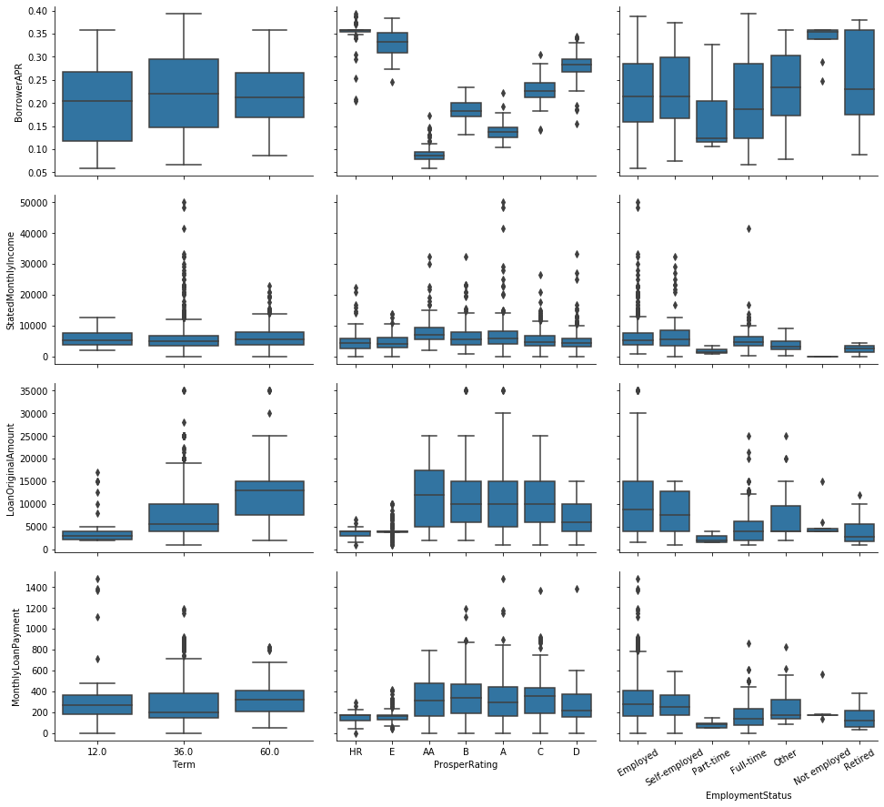

```python
# plot matrix of numeric features against categorical features.

samples = np.random.choice(df_n.shape[0], 2000, replace = False)
df_n_samp = df_n.loc[samples,:]

def boxgrid(x, y, **kwargs):
    """ Quick hack for creating box plots with seaborn's PairGrid. """
    default_color = sb.color_palette()[0]
    sb.boxplot(x, y, color = default_color)

plt.figure(figsize = [8, 10])
g = sb.PairGrid(data = df_n_samp, y_vars =  ['BorrowerAPR', 'StatedMonthlyIncome', 'LoanOriginalAmount', 'MonthlyLoanPayment'], x_vars = categoric_vars,
                height = 3, aspect = 1.5)
g.map(boxgrid)
plt.xticks(rotation = 30);
plt.show();
```

Finally, let's look at relationships between the three categorical features.

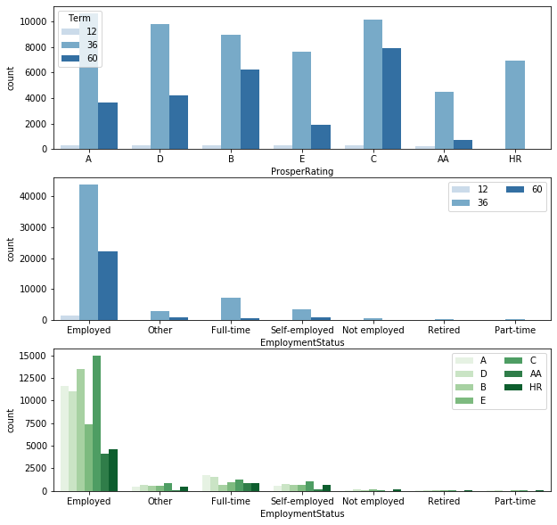

```python
# since there's only three subplots to create, using the full data should be fine.
plt.figure(figsize = [10, 10])

# subplot 1: ProsperRating vs term
plt.subplot(3, 1, 1)
sb.countplot(data = df_n, x = 'ProsperRating', hue = 'Term', palette = 'Blues')

# subplot 2: EmploymentStatus vs. Term
ax = plt.subplot(3, 1, 2)
sb.countplot(data = df_n, x = 'EmploymentStatus', hue = 'Term', palette = 'Blues')
ax.legend(ncol = 2) # re-arrange legend to reduce overlapping

# subplot 3: ProsperRating vs. EmploymentStatus, use different color palette
ax = plt.subplot(3, 1, 3)
sb.countplot(data = df_n, x = 'EmploymentStatus', hue = 'ProsperRating', palette = 'Greens')
ax.legend(loc = 1, ncol = 2) # re-arrange legend to remove overlapping

plt.show()
```

High Prosper Ratings (AA-A) loans have 36 months duration. There are more 60 month loans on B and C ratings. There is only 36 months loans for HR rating borrowers. Employment Status feature doesn't provide us with any informatioin, since there is only few data about non employed people.

## Multivariate Exploration

> The main thing I want to explore in this part of the analysis is how the categorical variable (Prosper rating and Term) play into the relationship between borrower APR and loan original amount.

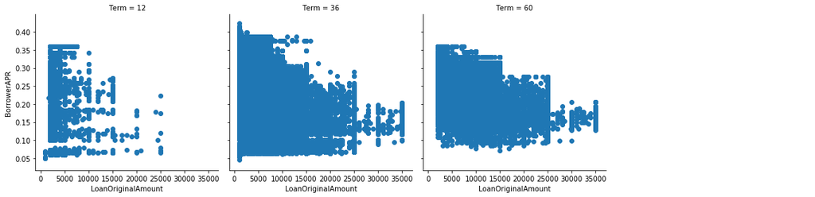

```python
## create faceted plot on levels of the Term variable
g=sb.FacetGrid(data=df_n, aspect=1, height=4, col='Term', col_wrap=4)
g.map(plt.scatter, 'LoanOriginalAmount', 'BorrowerAPR');
g.add_legend();
```

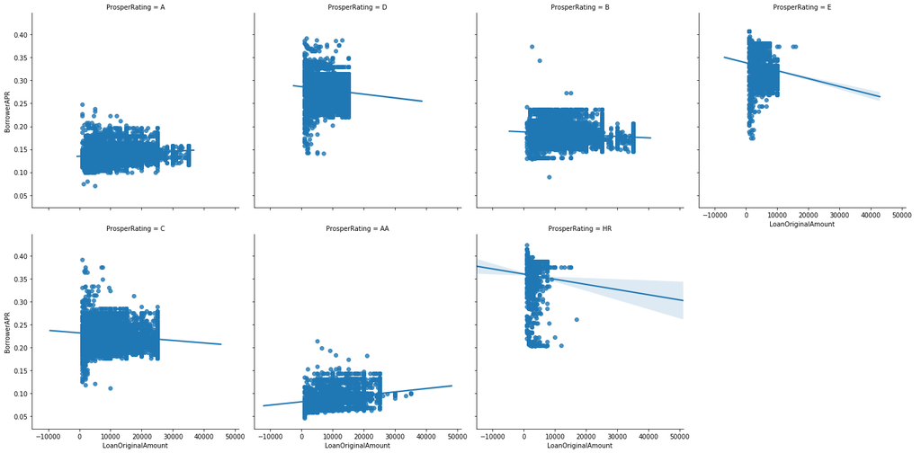

```python
# Prosper rating effect on relationship of APR and loan amount
g=sb.FacetGrid(data=df_n, aspect=1, height=5, col='ProsperRating', col_wrap=4)
g.map(sb.regplot, 'LoanOriginalAmount', 'BorrowerAPR');
g.add_legend();
```

Rating AA and A, which are the lowest risk, have a postive correlation. From B to HR, it is negative correlation.

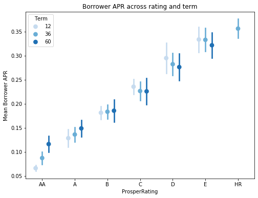

```python
rate_order =['AA', 'A', 'B', 'C', 'D', 'E', 'HR']
fig = plt.figure(figsize = [8,6])
ax = sb.pointplot(data = df_n, x = 'ProsperRating', y = 'BorrowerAPR', hue = 'Term', order=rate_order,
           palette = 'Blues', linestyles = '', dodge = 0.4, ci='sd')
plt.title('Borrower APR across rating and term')
plt.ylabel('Mean Borrower APR')
ax.set_yticklabels([],minor = True);
```

The borrower APR decreases with the increasingly better rating. Borrowers with the best Prosper ratings have the lowest APR.

Next: The rating and term effects on stated monthly income and loan original amount variables.

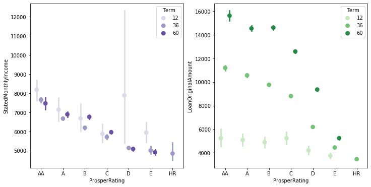

```python
rate_order =['AA', 'A', 'B', 'C', 'D', 'E', 'HR']
fig, ax = plt.subplots(ncols=2, figsize=[12,6])
sb.pointplot(data = df_n, x = 'ProsperRating', y = 'StatedMonthlyIncome', hue = 'Term', order=rate_order,
           palette = 'Purples', linestyles = '', dodge = 0.4, ax=ax[0])
sb.pointplot(data = df_n, x = 'ProsperRating', y = 'LoanOriginalAmount', hue = 'Term',order=rate_order,
           palette = 'Greens', linestyles = '', dodge = 0.4, ax=ax[1]);
```

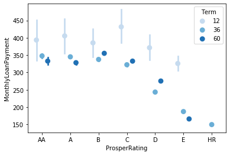

```python
sb.pointplot(data = df_n, x = 'ProsperRating', y = 'MonthlyLoanPayment', hue = 'Term',order=rate_order,
           palette = 'Blues', linestyles = '', dodge = 0.4, );
```

As we can see, accounts with high prosper rating tend to have high stated income and large loan amount. As a results of large loan amount, the monthly loan payments are high with high prosper rating accounts.

### Were there any interesting or surprising interactions between features?

> Looking back on the point plots, the only surprising interaction is when the prosper rating (A, AA) tend to have a postive correlation between borrower APR and loan amount.